# Thesis Summary

## Objective

Investigate the genetic association between blood plasma proteins and Alzheimer’s Disease (AD) to inform disease prediction and provide signals for functional research

- Identify a shortlist of blood plasma proteins from existing literature that have been associated with AD or AD phenotypes
- Create polygenic risk score (PRS) models for shortlist of proteins and test their association with AD in three cohorts (GERAD, ADNI and ANM)
- Assess bi-directional genetic association between shortlist of proteins and AD by creating an AD PRS model and testing association with blood plasma protein levels in ANM participants
- Test for causality by conducting Mendelian Randomization (MR) on selected SNPs from blood plasma proteins that are significant in one or both PRS analyses

## Graphical Abstract

[figure not shown]

## Results

### Step 1 - Select target proteins

71 candidate proteins were identified from a literature review of 33 papers.  
Proteins were marked as candidates if significantly associated with an AD related phenotype in an independent discovery study (univariate or multivariate) or if previously replicated in 3 or more studies in Kiddle et al’s comprehensive 2014 review.

25 proteins with GWAS data from Sun et al were selected for further analysis.

##### Figure 1: Target proteins for further analysis

| Protein | SOMAmerID | Protein Short Code | UniProtID | Number of studies where significant association with AD phenotype |
| --- | --- | --- | --- | --- |
| Apolipoprotein E | APOE.2937.10.2 | APOE | P02649 | 7 |
| Pancreatic prohormone | PPY.4588.1.2 | PPY | P01298 | 7 |
| Complement C3 | C3.2755.8.2 | C3 | P01024 | 6 |
| Complement factor H | CFH.4159.130.1 | CFH | P08603 | 6 |
| Clusterin | CLU.4542.24.2 | CLU | P10909 | 5 |
| Plasma protease C1 inhibitor | SERPING1.4479.14.2 | SERPING1 | P05155 | 5 |
| Serum amyloid P component | APCS.2474.54.5 | APCS | P02743 | 5 |
| Insulin-like growth factor-binding protein 2 | IGFBP2.2570.72.5 | IGFBP2 | P18065 | 4 |
| Interleukin-10 | IL10.2773.50.2 | IL10 | P22301 | 4 |
| Interleukin-3 | IL3.4717.55.2 | IL3 | P08700 | 4 |
| Vitronectin | VTN.13125.45.3 | VTN | P04004 | 4 |
| Fibronectin | FN1.3435.53.2 | FN1 | P02751 | 3 |
| Granulocyte colony-stimulating factor | CSF3.8952.65.3 | CSF3 | P09919 | 3 |
| Haptoglobin | HP.3054.3.2 | HP | P00738 | 3 |
| Complement C4 A/B | C4A.C4B.4481.34.2 | C4A | P0C0L4,P0C0L5 | 2 |
| Complement component C6 | C6.4127.75.1 | C6 | P13671 | 2 |
| Alpha-2-HS-glycoprotein | AHSG.3581.53.3 | AHSG | P02765 | 1 |
| Amyloid beta A4 protein | APP.3171.57.2 | APP | P05067 | 1 |
| Amyloid-beta A4 precursor protein-binding family B member 3 | APBB3.13589.10.3 | APBB3 | O95704 | 1 |
| Brain-derived neurotrophic factor | BDNF.2421.7.3 | BDNF | P23560 | 1 |
| Fibrinogen gamma chain | FGA.FGB.FGG.4907.56.1 | FGA | P02671,P02675,P02679 | 1 |
| Fibulin-1 | FBLN1.6470.19.3 | FBLN1 | P23142 | 1 |
| Inter-alpha-trypsin inhibitor heavy chain H1 | ITIH1.7955.195.3 | ITIH1 | P19827 | 1 |
| Prostate-specific antigen | KLK3.8468.19.3 | KLK3 | P07288 | 1 |
| Receptor tyrosine-protein kinase erbB-2 | ERBB2.2616.23.18 | ERBB2 | P04626 | 1 |

### Step 2 - Protein PRS -> AD status

##### Data Preparation

Summary GWAS statistics for the 25 target proteins were downloaded from the repository provided by the [Cambridge Cardiovascular Epidemiology Unit](http://www.phpc.cam.ac.uk/ceu/proteins/) based on 3,301 healthy individuals *(‘Base data’)*.

Raw genotype data from GERAD, ADNI and ANM for 6244 individuals accessed via KCL Rosalind High Performance Computing cluster *(‘Target data’)*.

Consistent QC applied **[REQUIRES VALIDATION]**  
Samples: European ancestry, non-relatives, no other dementia or mild cognitive impairment, call rate > 98%  
SNPs: MAF >0.01, call rate > 98%, HWE p<10^-5, imputed with INFO quality score >0.7

Only SNPs genotyped in all three Target data samples were selected from the Base data SNPs resulting in 5,210,103 SNPs for consideration in the PRS model.

##### Figure 2: Target sample summary

|  | ADNI | ANM | GERAD | TOTAL |
| --- | --- | --- | --- | --- |
| Cases | 639 | 371 | 3277 | 4287 |
| Controls | 368 | 374 | 1215 | 1957 |
| Total | 1007 | 745 | 4492 | 6244 |

##### Protein Heritability

Observed protein heritability (h2) was estimated using linkage disequilibrium score regression (LDSR).  
Average mean chi squared was low at 1.014048.  
Results treated as indicative given average SE of 0.192148 and known challenges of applying LDSR to samples <5,000.

##### Figure 3: Protein Heritability Estimates

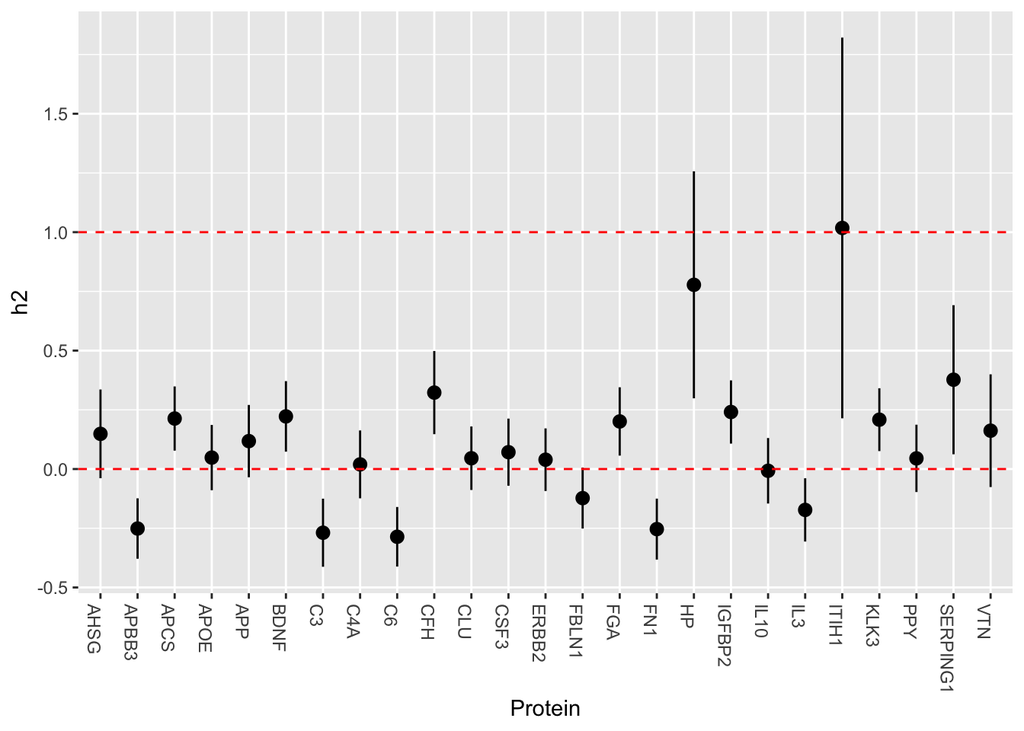

##### Protein PRS Models

```
#PRSice command to generate independent PRS models

Rscript /mnt/lustre/groups/proitsi/Jodie/prs/Programmes/PRSice.R \
      --dir /mnt/lustre/groups/proitsi/Alex/PRS_Outputs_All_Covariates \
      --prsice /mnt/lustre/groups/proitsi/Jodie/prs/Programmes/PRSice_linux \
      --base $PROTEIN_PATH \
      --target $TARGET_FILE \
      --stat BETA \
      --score std \
      --binary-target T \
      --prevalence 0.07 \
      --cov-file $TARGET_COVARIATE_FILE \
      --cov-col PC1,PC2,PC3,PC4,PC5,PC6,PC7,AGE,SEX \
      --bar-levels 5e-8,5e-5,5e-4,0.001,0.01,0.05,0.1,0.2,0.5,1 \
      --fastscore \
      --out /mnt/lustre/groups/proitsi/Alex/PRS_Outputs_All_Covariates/$OUTPUT

#Example code for meta-analysis
for (protein in proteins){
  print("Select data from each of the 10 thresholds")
    test1<-prsResults %>% filter(Protein == protein, Threshold == 5e-08)
    ...
    test10<-prsResults %>% filter(Protein == protein, Threshold == 1)

  print("Run meta analysis on each threshold")
    if(exists("test1")) test1.reml<-rma(yi=Coefficient, sei=Standard.Error, method="REML", data=test1)
    ...
    if(exists("test10")) test10.reml<-rma(yi=Coefficient, sei=Standard.Error, method="REML", data=test10)
```

##### Figure 5a: Proteins with Protein PRS significantly associated with AD

| Protein | ShortCode | P | R^2 |
| --- | --- | --- | --- |
| Complement component C6 | C6 | 0.0242 | 0.000814 |
| Plasma protease C1 inhibitor | SERPING1 | 0.0256 | 0.000799 |
| Inter-alpha-trypsin inhibitor heavy chain H1 | ITIH1 | 0.0272 | 0.000782 |
| Serum amyloid P component | APCS | 0.0283 | 0.000771 |
| Prostate-specific antigen | KLK3 | 0.0398 | 0.000678 |
| Insulin-like growth factor-binding protein 2 | IGFBP2 | 0.0435 | 0.000653 |

##### Figure 5b: Protein PRS Associations with AD (Meta-analysed, No APOE SNPs)

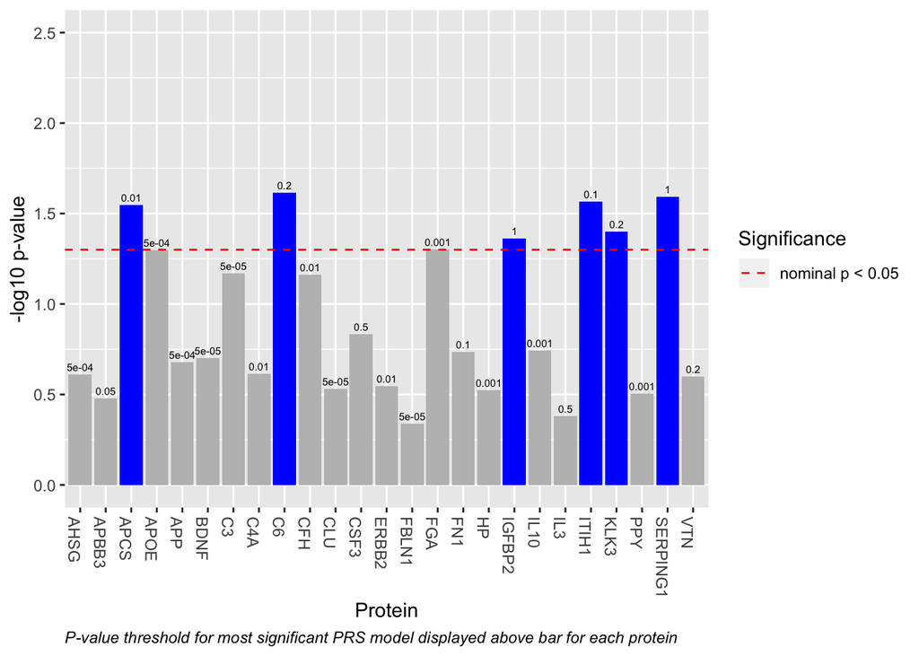

##### Figure 6: Protein PRS Associations with AD (Per sample, No APOE SNPs)

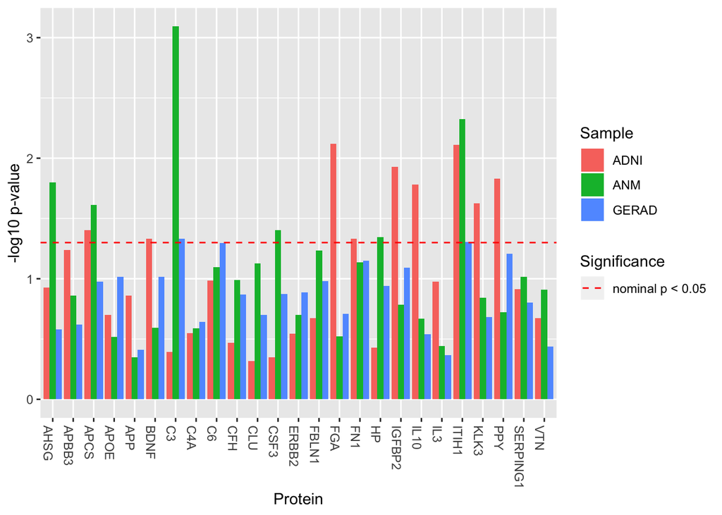

### Step 3 - AD PRS -> protein

##### AD PRS Models

PRS model built for AD using Kunkle et al GWAS summary statistics and tested for association with the 20 proteins which had blood plasma protein levels collected in the ANM cohort.  
For pancreatic prohormone, amyloid-beta A4 precursor protein-binding family B member 3, fibulin-1, inter-alpha-trypsin inhibitor heavy chain H1 and vitronectin no protein level data available.

##### Figure 7: ANM target sample summary

[output not shown]

```
#PRSice command to generate AD PRS models

Rscript /mnt/lustre/groups/proitsi/Jodie/prs/Programmes/PRSice.R \
--dir /mnt/lustre/groups/proitsi/Alex/AD_PRS_to_Protein/PRS_Outputs \
--prsice /mnt/lustre/groups/proitsi/Jodie/prs/Programmes/PRSice_linux \
--base /mnt/lustre/groups/proitsi/Alex/AD_PRS_to_Protein/Base_Data/Post_QC/Kunkle_Stage1_post_qc.txt \
--target /mnt/lustre/groups/proitsi/Alex/AD_PRS_to_Protein/Target_Data/three_batches_imputed.pQTL.QC \
--chr Chromosome \
--bp Position \
--snp  MarkerName \
--A1 Effect_allele \
--A2 Non_Effect_allele \
--stat Beta \
--pvalue Pvalue \
--score std \
--binary-target F,F,F,F,F,F,F,F,F,F,F,F,F,F,F,F,F,F,F,F \
--pheno /mnt/lustre/groups/proitsi/Alex/AD_PRS_to_Protein/Target_Data/SOMA_Pheno_Oct19 \
--pheno-col $TARGET_PROTEINS \
--bar-levels 5e-8,5e-5,5e-4,0.001,0.01,0.05,0.1,0.2,0.5,1 \
--fastscore \
--out /mnt/lustre/groups/proitsi/Alex/AD_PRS_to_Protein/PRS_Outputs/Kunkle_AD_to_ANM_WITH_APOE
```

##### Figure 8a: Proteins significantly associated with AD PRS

| Protein | ShortCode | P | R^2 |
| --- | --- | --- | --- |
| Interleukin-10 | IL10 | 0.0392 | 0.01040 |
| Haptoglobin | HP | 0.0460 | 0.00974 |

##### Figure 8b: AD PRS Associations with blood plasma protein levels (No APOE SNPs)

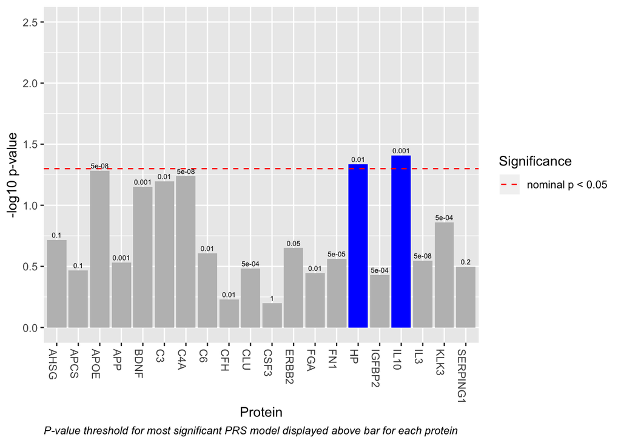

### Step 4 - Bidirectional MR

Proteins that were significant in one or both PRS were considered for Mendelian Randomisation (MR).  
This resulted in 9 proteins, including APOE.

Genetic instruments for each protein were selected and analysed in three tiers of descending conservatism.  
+ Tier 1 - sentinal variant cis-only pQTLs as defined by Sun et al (p < 1.5e11)  
+ Tier 2 - SNPs with p < 5e08 clumped based on LD r2 <0.001 within a 250kb window (to provide n>1 instruments)  
+ Tier 3 - SNPs with p < 5e06 clumped based on LD r2 <0.001 within a 250kb window (to provide instruments for all 9 proteins and account for polygenic architecture)

Genetic instruments were screened for:  
+ Association with other blood plasma proteins in Sun et al (horizontal pleiotropy)  
+ Association with other potential risk exposures (horizontal pleiotropy)  
+ Association with AD through the exposure only (vertical pleiotropy)

##### Figure 9: Proteins for MR

| Protein | ShortCode | Protein PRS -> AD | AD PRS -> Protein | Tier 1 (n SNPs) | Tier 2 (n SNPs) | Tier 3 (n SNPs) | AD (n SNPs) |
| --- | --- | --- | --- | --- | --- | --- | --- |
| Apolipoprotein E | APOE | Y | Y | NA | NA | 13 | 17 |
| Complement component C6 | C6 | Y | N | NA | 1 | 7 | 17 |
| Haptoglobin | HP | N | Y | 1 | 14 | 27 | 17 |
| Insulin-like growth factor-binding protein 2 | IGFBP2 | Y | N | NA | NA | 8 | 17 |
| Inter-alpha-trypsin inhibitor heavy chain H1 | ITIH1 | Y | N | 1 | 7 | 21 | 17 |
| Interleukin-10 | IL10 | N | Y | NA | 1 | 6 | 17 |
| Plasma protease C1 inhibitor | SERPING1 | Y | N | 1 | 5 | 17 | 17 |
| Prostate-specific antigen | KLK3 | Y | N | NA | NA | 9 | 17 |
| Serum amyloid P component | APCS | Y | N | 1 | 3 | 10 | 17 |

Proteins were analysed individually as an exposure with AD as the outcome. AD was then used as an exposure with each protein as the outcome to test for reverse causality.  
Inverse variance weighted MR and sensitivity analysis (e.g. weighted median, weighted mode, MR Egger) was conducted using the R package [MR Base](https://mrcieu.github.io/TwoSampleMR/).

##### Figure 10: MR Results

| Protein | ShortCode | Tier 1 min p | Tier 2 min p | Tier 3 min p | AD min p |
| --- | --- | --- | --- | --- | --- |
| Haptoglobin | HP | 0.021 | 0.1147 | 0.0177 | 0.047239835058 |
| Plasma protease C1 inhibitor | SERPING1 | 0.130 | 0.0616 | 0.0838 | 0.693418101122 |
| Serum amyloid P component | APCS | 0.557 | 0.1989 | 0.3371 | 0.204790887080 |
| Inter-alpha-trypsin inhibitor heavy chain H1 | ITIH1 | 0.654 | 0.5370 | 0.3221 | 0.583447812755 |
| Apolipoprotein E | APOE | NA | NA | 0.3871 | 0.000000000112 |
| Interleukin-10 | IL10 | NA | 0.7962 | 0.3018 | 0.144925185291 |
| Complement component C6 | C6 | NA | 0.0200 | 0.1175 | 0.268592892873 |
| Prostate-specific antigen | KLK3 | NA | NA | 0.2290 | 0.524624714681 |
| Insulin-like growth factor-binding protein 2 | IGFBP2 | NA | NA | 0.3485 | 0.266504373232 |